# IP WEEK 12

IYLINE CHUMO

26/08/2021

## Defining The Question

To identify which individuals are most likely to click on an online cryptography course advert.

## Metric of Success

Our project will be considered successful if we are able to effectively perform EDA to determine the individuals who are most likely to click the ads.

## Understanding the context

A Kenyan entrepreneur has created an online cryptography course and would want to advertise it on her blog. She currently targets audiences originating from various countries. In the past, she ran ads to advertise a related course on the same blog and collected data in the process. She would now like to employ our services as Data Scientists Consultants identify which individuals are most likely to click on her ads.

## Experimental Design

- Loading the dataset
- Performing data cleaning
- Exploratory Data Analysis
- Conclusion and recommendation

## Loading the Dataset

```r
data <- read.csv('http://bit.ly/IPAdvertisingData')
```

```r
head(data)
```

```
##   Daily.Time.Spent.on.Site Age Area.Income Daily.Internet.Usage
## 1                    68.95  35    61833.90               256.09
## 2                    80.23  31    68441.85               193.77
## 3                    69.47  26    59785.94               236.50
## 4                    74.15  29    54806.18               245.89
## 5                    68.37  35    73889.99               225.58
## 6                    59.99  23    59761.56               226.74
##                           Ad.Topic.Line           City Male    Country
## 1    Cloned 5thgeneration orchestration    Wrightburgh    0    Tunisia
## 2    Monitored national standardization      West Jodi    1      Nauru
## 3      Organic bottom-line service-desk       Davidton    0 San Marino
## 4 Triple-buffered reciprocal time-frame West Terrifurt    1      Italy
## 5         Robust logistical utilization   South Manuel    0    Iceland
## 6       Sharable client-driven software      Jamieberg    1     Norway
##             Timestamp Clicked.on.Ad
## 1 2016-03-27 00:53:11             0
## 2 2016-04-04 01:39:02             0
## 3 2016-03-13 20:35:42             0
## 4 2016-01-10 02:31:19             0
## 5 2016-06-03 03:36:18             0
## 6 2016-05-19 14:30:17             0
```

```r
tail(data)
```

```
##      Daily.Time.Spent.on.Site Age Area.Income Daily.Internet.Usage
## 995                     43.70  28    63126.96               173.01
## 996                     72.97  30    71384.57               208.58
## 997                     51.30  45    67782.17               134.42
## 998                     51.63  51    42415.72               120.37
## 999                     55.55  19    41920.79               187.95
## 1000                    45.01  26    29875.80               178.35
##                             Ad.Topic.Line          City Male
## 995         Front-line bifurcated ability  Nicholasland    0
## 996         Fundamental modular algorithm     Duffystad    1
## 997       Grass-roots cohesive monitoring   New Darlene    1
## 998          Expanded intangible solution South Jessica    1
## 999  Proactive bandwidth-monitored policy   West Steven    0
## 1000      Virtual 5thgeneration emulation   Ronniemouth    0
##                     Country           Timestamp Clicked.on.Ad
## 995                 Mayotte 2016-04-04 03:57:48             1
## 996                 Lebanon 2016-02-11 21:49:00             1
## 997  Bosnia and Herzegovina 2016-04-22 02:07:01             1
## 998                Mongolia 2016-02-01 17:24:57             1
## 999               Guatemala 2016-03-24 02:35:54             0
## 1000                 Brazil 2016-06-03 21:43:21             1
```

## Finding the total missing values in our dataset.

```r
colSums(is.na(data))
```

```
## Daily.Time.Spent.on.Site                      Age              Area.Income
##                        0                        0                        0
##     Daily.Internet.Usage            Ad.Topic.Line                     City
##                        0                        0                        0
##                     Male                  Country                Timestamp
##                        0                        0                        0
##            Clicked.on.Ad
##                        0
```

there are no missing values in our dataset

##Checking for duplicates across our rows.

```r
data[duplicated(data),]
```

```
##  [1] Daily.Time.Spent.on.Site Age                      Area.Income
##  [4] Daily.Internet.Usage     Ad.Topic.Line            City
##  [7] Male                     Country                  Timestamp
## [10] Clicked.on.Ad
## <0 rows> (or 0-length row.names)
```

there are no duplicated values in our dataset

## Exploring the dataset

#Checking the descriptive statistics of our dataset

```r
summary(data)
```

```
##  Daily.Time.Spent.on.Site      Age         Area.Income    Daily.Internet.Usage
##  Min.   :32.60            Min.   :19.00   Min.   :13996   Min.   :104.8
##  1st Qu.:51.36            1st Qu.:29.00   1st Qu.:47032   1st Qu.:138.8
##  Median :68.22            Median :35.00   Median :57012   Median :183.1
##  Mean   :65.00            Mean   :36.01   Mean   :55000   Mean   :180.0
##  3rd Qu.:78.55            3rd Qu.:42.00   3rd Qu.:65471   3rd Qu.:218.8
##  Max.   :91.43            Max.   :61.00   Max.   :79485   Max.   :270.0
##  Ad.Topic.Line          City                Male         Country
##  Length:1000        Length:1000        Min.   :0.000   Length:1000
##  Class :character   Class :character   1st Qu.:0.000   Class :character
##  Mode  :character   Mode  :character   Median :0.000   Mode  :character
##                                        Mean   :0.481
##                                        3rd Qu.:1.000
##                                        Max.   :1.000
##   Timestamp         Clicked.on.Ad
##  Length:1000        Min.   :0.0
##  Class :character   1st Qu.:0.0
##  Mode  :character   Median :0.5
##                     Mean   :0.5
##                     3rd Qu.:1.0
##                     Max.   :1.0
```

##Checking the structure of our dataframe

```r
str(data)
```

```
## 'data.frame':    1000 obs. of  10 variables:
##  $ Daily.Time.Spent.on.Site: num  69 80.2 69.5 74.2 68.4 ...
##  $ Age                     : int  35 31 26 29 35 23 33 48 30 20 ...
##  $ Area.Income             : num  61834 68442 59786 54806 73890 ...
##  $ Daily.Internet.Usage    : num  256 194 236 246 226 ...
##  $ Ad.Topic.Line           : chr  "Cloned 5thgeneration orchestration" "Monitored national standardization" "Organic bottom-line service-desk" "Triple-buffered reciprocal time-frame" ...
##  $ City                    : chr  "Wrightburgh" "West Jodi" "Davidton" "West Terrifurt" ...
##  $ Male                    : int  0 1 0 1 0 1 0 1 1 1 ...
##  $ Country                 : chr  "Tunisia" "Nauru" "San Marino" "Italy" ...
##  $ Timestamp               : chr  "2016-03-27 00:53:11" "2016-04-04 01:39:02" "2016-03-13 20:35:42" "2016-01-10 02:31:19" ...
##  $ Clicked.on.Ad           : int  0 0 0 0 0 0 0 1 0 0 ...
```

##checking for outliers plotting the boxplots to to check the data distribution in the numeric columns

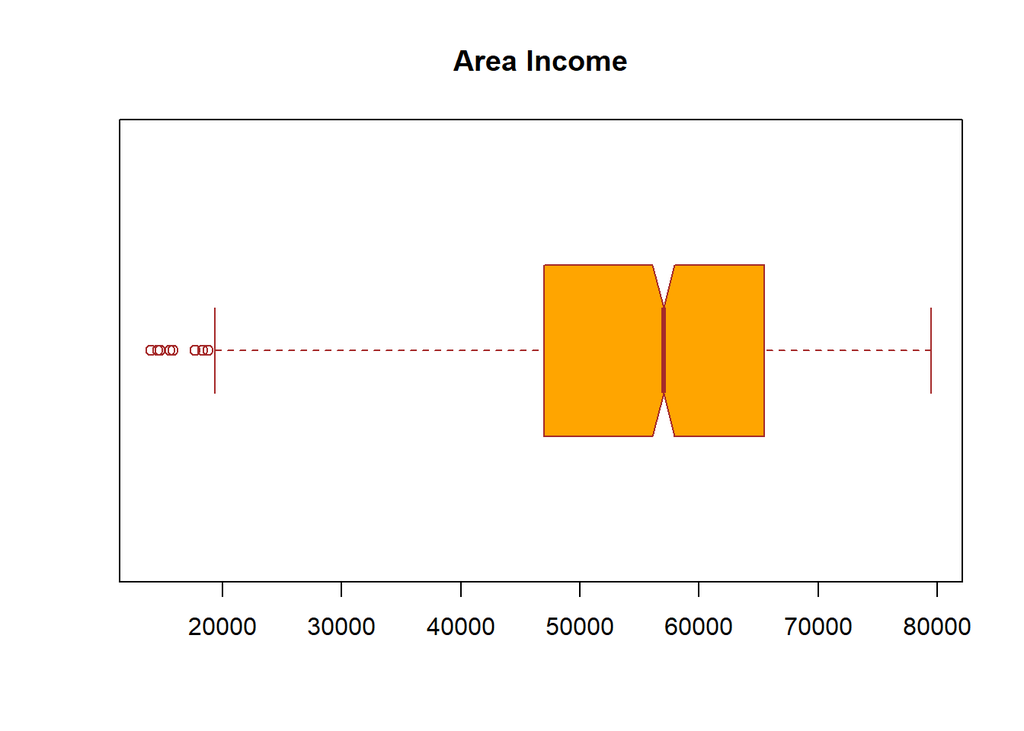

```r
boxplot(data$Area.Income,
        main ="Area Income",
        col = "orange",
        border  = 'brown',
        horizontal = TRUE,
        notch = TRUE)
```

There are a few outliers in the area.income column

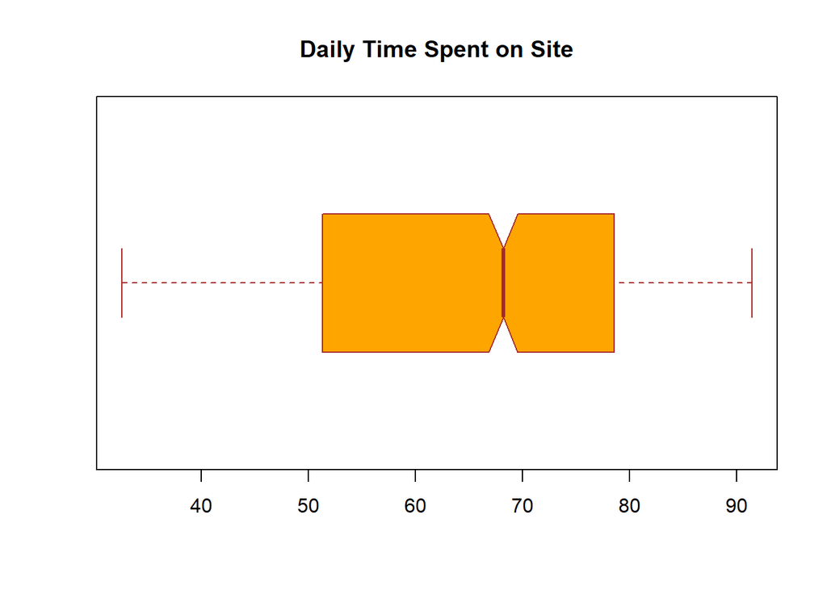

```r
boxplot(data$Daily.Time.Spent.on.Site,
        main ="Daily Time Spent on Site",
        col = "orange",
        border  = 'brown',
        horizontal = TRUE,
        notch = TRUE)
```

There are no outliers in time spent on site column.

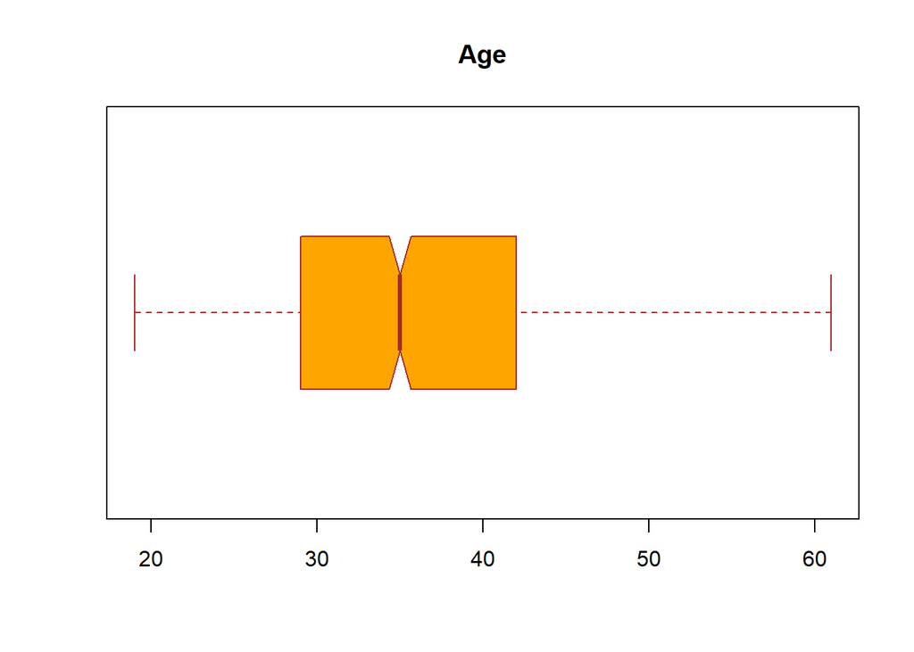

```r
boxplot(data$Age,
        main ="Age",
        col = "orange",
        border  = 'brown',
        horizontal = TRUE,
        notch = TRUE)
```

There are no outliers in the age column

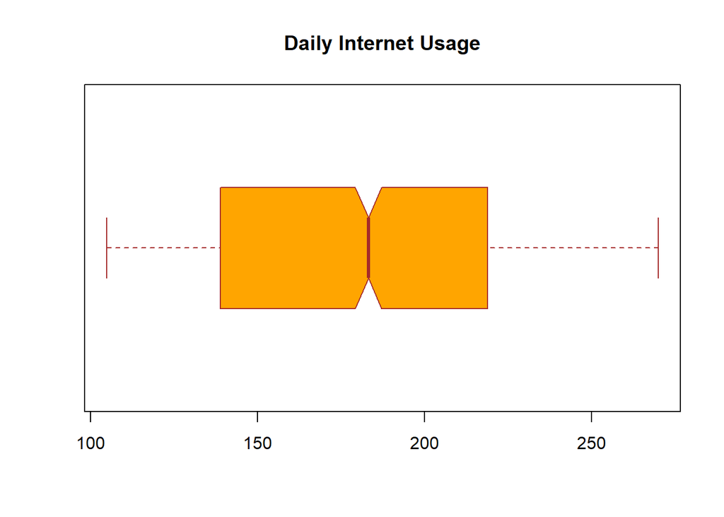

```r
boxplot(data$Daily.Internet.Usage,
        main ="Daily Internet Usage",
        col = "orange",
        border  = 'brown',
        horizontal = TRUE,
        notch = TRUE)
```

```r
#There are no outliers in the daily internet usage column
```

## Exploratory Data Analysis

### Univariate Analysis

#### Measures of Central Tendency

#Finding the mean of our numeric columns

```r
colMeans(data[sapply(data,is.numeric)])
```

```
## Daily.Time.Spent.on.Site                      Age              Area.Income
##                  65.0002                  36.0090               55000.0001
##     Daily.Internet.Usage                     Male            Clicked.on.Ad
##                 180.0001                   0.4810                   0.5000
```

#Finding the median of our numeric columns

```r
ad_time_median <- median(data$Daily.Time.Spent.on.Site)
print(ad_time_median)
```

```
## [1] 68.215
```

```r
ad_age_median <- median(data$Age)
ad_age_median
```

```
## [1] 35
```

```r
ad_income_median <- median(data$Area.Income)
ad_income_median
```

```
## [1] 57012.3
```

```r
ad_internet_usage_median <- median(data$Daily.Internet.Usage)
ad_internet_usage_median
```

```
## [1] 183.13
```

Finding the mode of our numeric columns. creating the mode function

```r
getmode <- function(v) {
   uniqv <- unique(v)
   uniqv[which.max(tabulate(match(v, uniqv)))]}
```

```r
getmode(data$Age)
```

```
## [1] 31
```

```r
getmode(data$Daily.Time.Spent.on.Site)
```

```
## [1] 62.26
```

```r
getmode(data$Area.Income)
```

```
## [1] 61833.9
```

```r
getmode(data$Daily.Internet.Usage)
```

```
## [1] 167.22
```

```r
getmode(data$City)
```

```
## [1] "Lisamouth"
```

```r
getmode(data$Ad.Topic.Line)
```

```
## [1] "Cloned 5thgeneration orchestration"
```

```r
getmode(data$Male)
```

```
## [1] 0
```

```r
getmode(data$Country)
```

```
## [1] "Czech Republic"
```

```r
getmode(data$Timestamp)
```

```
## [1] "2016-03-27 00:53:11"
```

finding the minimum values in the numeric columns

```r
min(data$Age)
```

```
## [1] 19
```

```r
min(data$Daily.Time.Spent.on.Site)
```

```
## [1] 32.6
```

```r
min(data$Area.Income)
```

```
## [1] 13996.5
```

```r
min(data$Daily.Internet.Usage)
```

```
## [1] 104.78
```

Finding the maximum values in the numeric columns

```r
max(data$Age)
```

```
## [1] 61
```

```r
max(data$Daily.Time.Spent.on.Site)
```

```
## [1] 91.43
```

```r
max(data$Area.Income)
```

```
## [1] 79484.8
```

```r
max(data$Daily.Internet.Usage)
```

```
## [1] 269.96
```

Finding the range in the numeric columns

```r
range(data$Age)
```

```
## [1] 19 61
```

```r
range(data$Daily.Time.Spent.on.Site)
```

```
## [1] 32.60 91.43
```

```r
range(data$Area.Income)
```

```
## [1] 13996.5 79484.8
```

```r
range(data$Daily.Internet.Usage)
```

```
## [1] 104.78 269.96
```

- The youngest respondent is 19 and the oldest 61 years of age.
- The least time spent on her site is 32 minutes and the highest 91 minutes.
- The lowest income earner among the respondents earns 13,996 while the highest earns 79,484.
- Daily internet usage ranges from 105 - 270

#finding the stardard deviations of the columns

```r
sd(data$Age)
```

```
## [1] 8.785562
```

```r
sd(data$Daily.Time.Spent.on.Site)
```

```
## [1] 15.85361
```

```r
sd(data$Area.Income)
```

```
## [1] 13414.63
```

```r
sd(data$Daily.Internet.Usage)
```

```
## [1] 43.90234
```

#getting the quantiles in our columns

```r
quantile(data$Age)
```

```
##   0%  25%  50%  75% 100%
##   19   29   35   42   61
```

```r
quantile(data$Daily.Time.Spent.on.Site)
```

```
##      0%     25%     50%     75%    100%
## 32.6000 51.3600 68.2150 78.5475 91.4300
```

```r
quantile(data$Area.Income)
```

```
##       0%      25%      50%      75%     100%
## 13996.50 47031.80 57012.30 65470.64 79484.80
```

```r
quantile(data$Daily.Internet.Usage)
```

```
##       0%      25%      50%      75%     100%
## 104.7800 138.8300 183.1300 218.7925 269.9600
```

#### Frequency Distribution

Finding the frequency distribution in the age column

```r
table(data$Age)
```

```
##
## 19 20 21 22 23 24 25 26 27 28 29 30 31 32 33 34 35 36 37 38 39 40 41 42 43 44
##  6  6  6 13 19 21 27 37 33 48 48 39 60 38 43 39 39 50 36 37 30 36 32 26 23 21
## 45 46 47 48 49 50 51 52 53 54 55 56 57 58 59 60 61
## 30 18 13 16 18 20 12 15 10  9  7  2  6  4  2  4  1
```

```r
summary(data)
```

```
##  Daily.Time.Spent.on.Site      Age         Area.Income    Daily.Internet.Usage
##  Min.   :32.60            Min.   :19.00   Min.   :13996   Min.   :104.8
##  1st Qu.:51.36            1st Qu.:29.00   1st Qu.:47032   1st Qu.:138.8
##  Median :68.22            Median :35.00   Median :57012   Median :183.1
##  Mean   :65.00            Mean   :36.01   Mean   :55000   Mean   :180.0
##  3rd Qu.:78.55            3rd Qu.:42.00   3rd Qu.:65471   3rd Qu.:218.8
##  Max.   :91.43            Max.   :61.00   Max.   :79485   Max.   :270.0
##  Ad.Topic.Line          City                Male         Country
##  Length:1000        Length:1000        Min.   :0.000   Length:1000
##  Class :character   Class :character   1st Qu.:0.000   Class :character
##  Mode  :character   Mode  :character   Median :0.000   Mode  :character
##                                        Mean   :0.481
##                                        3rd Qu.:1.000
##                                        Max.   :1.000
##   Timestamp         Clicked.on.Ad
##  Length:1000        Min.   :0.0
##  Class :character   1st Qu.:0.0
##  Mode  :character   Median :0.5
##                     Mean   :0.5
##                     3rd Qu.:1.0
##                     Max.   :1.0
```

# Most respondents fall between the age bracket of 24-40years. The age with the highest number of readers is 31 which has a total of 60 people in total.

#### Histogram

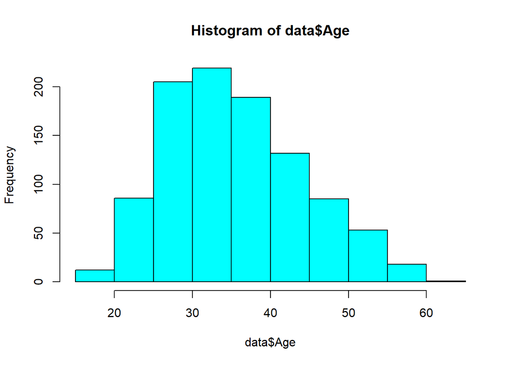

```r
hist(data$Age, col  = "Cyan")
```

#Most respondents fall in the age bracket of 25-40yrs.

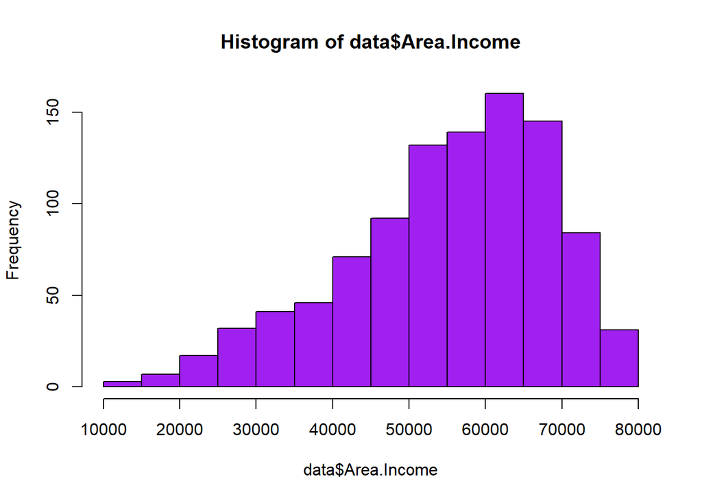

```r
hist(data$Area.Income, col = "Purple")
```

#Majority of the respondents earn between 50K - 70K

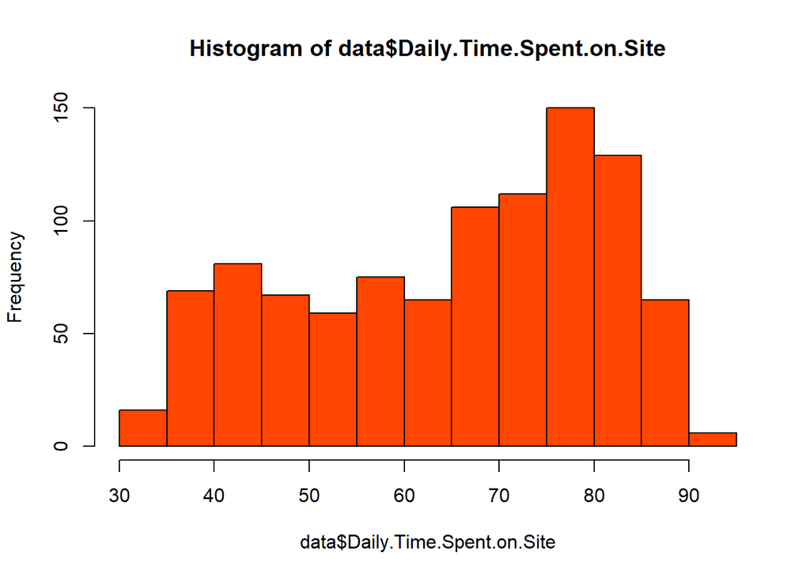

```r
hist(data$Daily.Time.Spent.on.Site, col = "orangered")
```

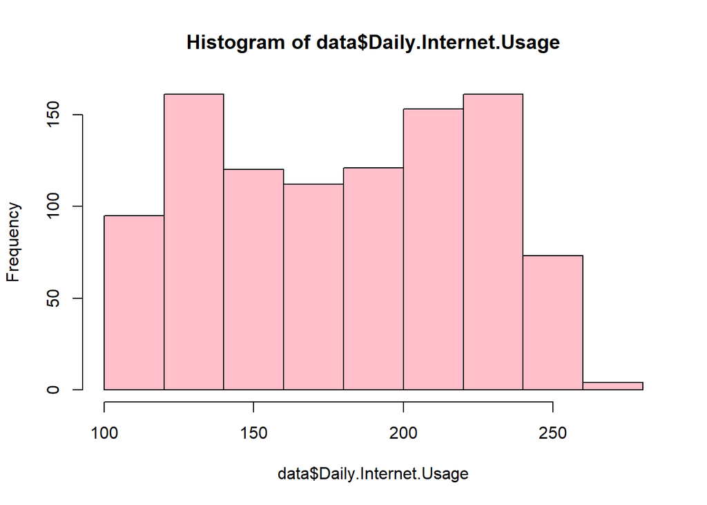

```r
hist(data$Daily.Internet.Usage, col = "pink")
```

### Bivariate Analysis

#### Covariance

```r
cov(data$Age, data$Daily.Time.Spent.on.Site)
```

```
## [1] -46.17415
```

#There is a negative relationship between the age and the time spent on site which means as the age increases, the daily time spent on the site decreases.

```r
cov(data$Age, data$Daily.Internet.Usage)
```

```
## [1] -141.6348
```

#There is a negative relationship between the age and the daily internet usage as well.

```r
cov(data$Area.Income,data$Daily.Time.Spent.on.Site)
```

```
## [1] 66130.81
```

```r
cov(data$Age,data$Area.Income)
```

```
## [1] -21520.93
```

#There is a negative correlation between the age and income variables.

#### Correlation matrix

```r
cor(data$Age, data$Daily.Time.Spent.on.Site)
```

```
## [1] -0.3315133
```

```r
cor(data$Age,data$Daily.Internet.Usage)
```

```
## [1] -0.3672086
```

```r
cor(data$Area.Income,data$Daily.Internet.Usage)
```

```
## [1] 0.3374955
```

```r
cor(data$Area.Income,data$Daily.Time.Spent.on.Site)
```

```
## [1] 0.3109544
```

```r
cor(data$Age,data$Area.Income)
```

```
## [1] -0.182605
```

```r
cor(data[, c("Age","Daily.Time.Spent.on.Site","Daily.Internet.Usage")])
```

```
##                                 Age Daily.Time.Spent.on.Site
## Age                       1.0000000               -0.3315133
## Daily.Time.Spent.on.Site -0.3315133                1.0000000
## Daily.Internet.Usage     -0.3672086                0.5186585
##                          Daily.Internet.Usage
## Age                                -0.3672086
## Daily.Time.Spent.on.Site            0.5186585
## Daily.Internet.Usage                1.0000000
```

```r
cor(data[,unlist(lapply(data, is.numeric))])
```

```
##                          Daily.Time.Spent.on.Site         Age  Area.Income
## Daily.Time.Spent.on.Site               1.00000000 -0.33151334  0.310954413
## Age                                   -0.33151334  1.00000000 -0.182604955
## Area.Income                            0.31095441 -0.18260496  1.000000000
## Daily.Internet.Usage                   0.51865848 -0.36720856  0.337495533
## Male                                  -0.01895085 -0.02104406  0.001322359
## Clicked.on.Ad                         -0.74811656  0.49253127 -0.476254628
##                          Daily.Internet.Usage         Male Clicked.on.Ad
## Daily.Time.Spent.on.Site           0.51865848 -0.018950855   -0.74811656
## Age                               -0.36720856 -0.021044064    0.49253127
## Area.Income                        0.33749553  0.001322359   -0.47625463
## Daily.Internet.Usage               1.00000000  0.028012326   -0.78653918
## Male                               0.02801233  1.000000000   -0.03802747
## Clicked.on.Ad                     -0.78653918 -0.038027466    1.00000000
```

##There are positive Correlations between the following variables: 1.Age and Clicking on the advert 2.Male and Daily Internet Usage 3.Male and Area Income 4.Daily Time Spent on Site and Daily Internet Usage. 5.Area Income and Daily Time Spent on Site 6.Area Income and Daily Internet Usage 7.Area Income and Male 8.Age and Clicking on the Advert.

#### Scatter Plots

A scatter plot for age and daily time spent on site.

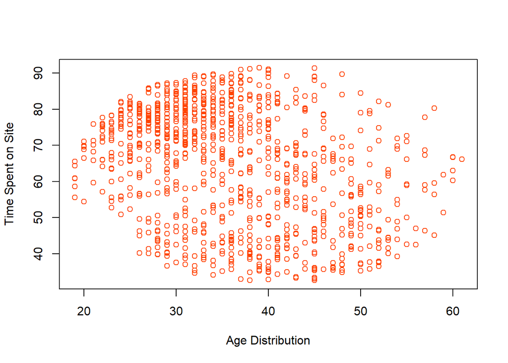

```r
plot(data$Age,data$Daily.Time.Spent.on.Site, xlab = "Age Distribution",
     ylab = "Time Spent on Site", col="orangered")
```

Scatter plot for Income Distribution and Daily time spent on site.

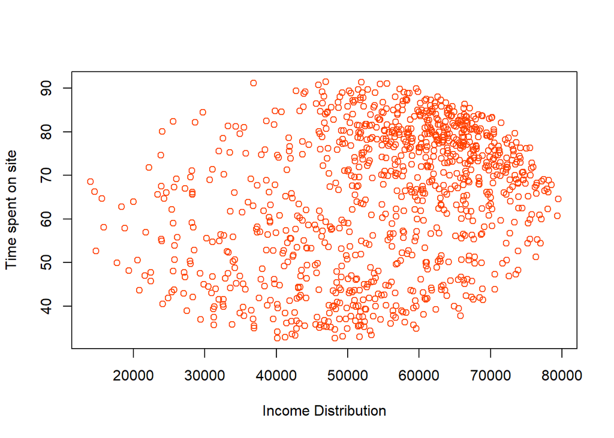

```r
plot(data$Area.Income,data$Daily.Time.Spent.on.Site, xlab= "Income Distribution", ylab = "Time spent on site", col="orangered")
```

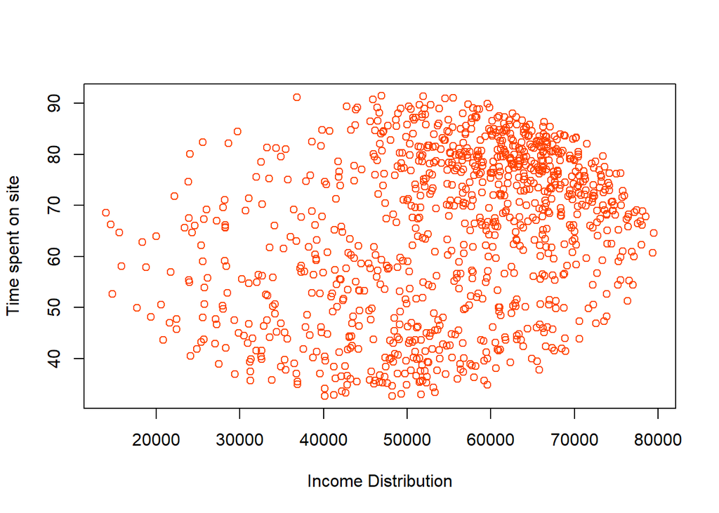

```r
plot(data$Area.Income,data$Daily.Time.Spent.on.Site, xlab= "Income Distribution", ylab = "Time spent on site", col="orangered")
```

Scatter plot for Age and Income Distribution

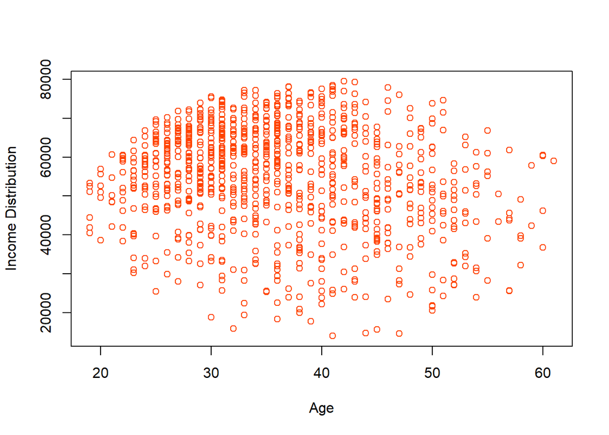

```r
plot(data$Age,data$Area.Income, xlab = "Age", ylab ="Income Distribution", col="orangered")
```

##Conclusion

## Follow up questions

### Did we have the right data?

Yes

### Do we need other data to answer our question?

No

### Did we have the right question?

Yes